# Final Report

Roy Budhaditya

April 28, 2019

## Data Description

Globtemp dataset consists of lobal mean land-ocean temperature deviations measured in degrees centigrade,  
with base period between 1880-2015 in degrees centigrade.Globtemp data is a time series from 1880-2015. This dataset is used to demonstrate empirical time series analysis.  
apparent upward trend in the series during the latter part of the twentieth century that has been used as an argument for the global warming hypothesis.

## Variable description and its statistical summary

Data are in mean deviation of land ocean temperature

```r
# Libraries
library(astsa)
library(astsa)
library(timeSeries)
library(tseries)
library(forecast)
library(xts)
library(TTR)
# Get dataset from astsa
data("globtemp")
class(globtemp)
```

```
## [1] "ts"
```

```r
# Statistics of globaltemp dataset
mean(globtemp)
```

```
## [1] 0.01838235
```

```r
mean(globtemp)
```

```
## [1] 0.01838235
```

```r
median(globtemp)
```

```
## [1] -0.075
```

```r
sd(globtemp)
```

```
## [1] 0.317339
```

```r
IQR(globtemp)
```

```
## [1] 0.3925
```

```r
mad(globtemp)
```

```
## [1] 0.289107
```

```r
summary(globtemp)
```

```
##     Min.  1st Qu.   Median     Mean  3rd Qu.     Max.
## -0.47000 -0.21000 -0.07500  0.01838  0.18250  0.87000
```

## Time series (ts) description

Time series is sequence of data in chronological order. There are basic four types of time series modesl,White Noise, Random walk, Autoregression, Simple Moving average. Building time series object with globtemp dataset.Here we are using start= 1880, end = 2015 and yearly frequency to build a time series object whcih will be useful for future analysis.

```r
gtemp=ts(globtemp,frequency=1,start=1880,end=2015)
head(gtemp,n=10)
```

```
## Time Series:
## Start = 1880
## End = 1889
## Frequency = 1
##  [1] -0.20 -0.11 -0.10 -0.20 -0.28 -0.31 -0.30 -0.33 -0.20 -0.11
```

# Plotting data

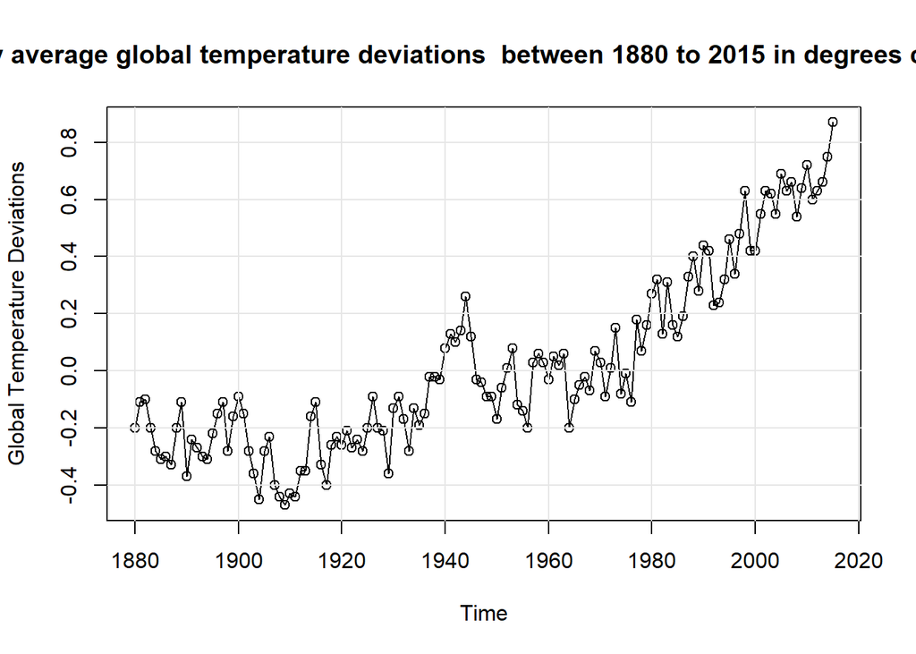

```r
plot(globtemp,main="Yearly average global temperature deviations  between 1880 to 2015 in degrees centigrade",type="o", ylab="Global Temperature Deviations")
grid(lty=1, col=gray(.9))
```

#boxplot

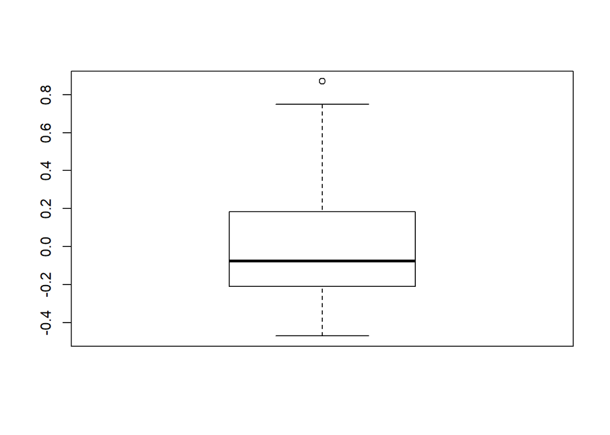

```r
boxplot(gtemp)
```

#ts plot with abline

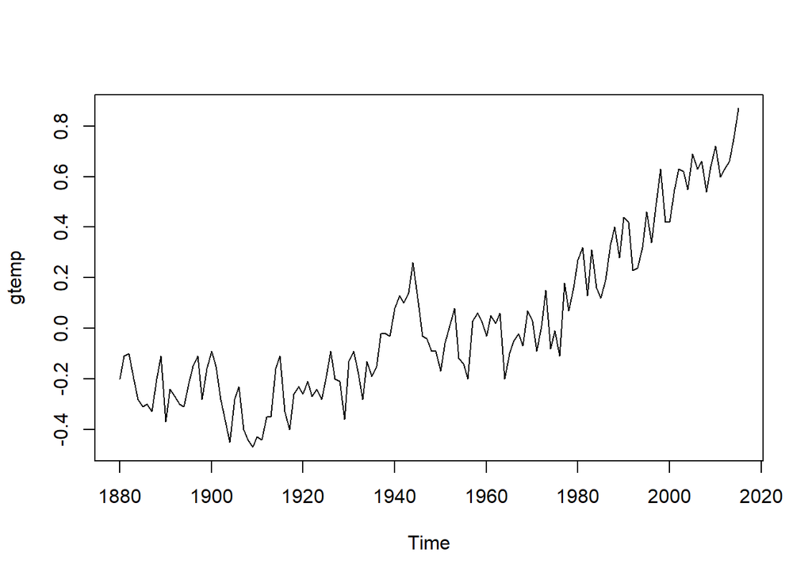

```r
ts.plot(gtemp)
```

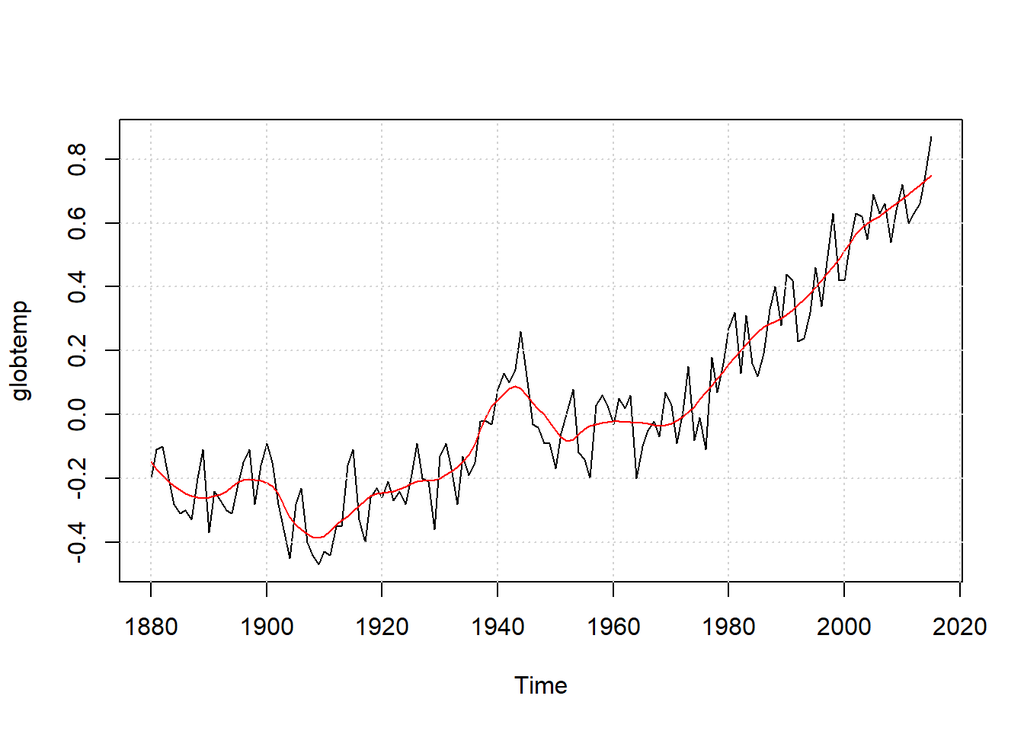

```r
tt <- 1:length(globtemp)
fit <- ts(loess(globtemp ~ tt, span = 0.2)$fitted, start = 1880, frequency = 1)
plot(globtemp, type='l')
lines(fit, col = 'red')
grid()
```

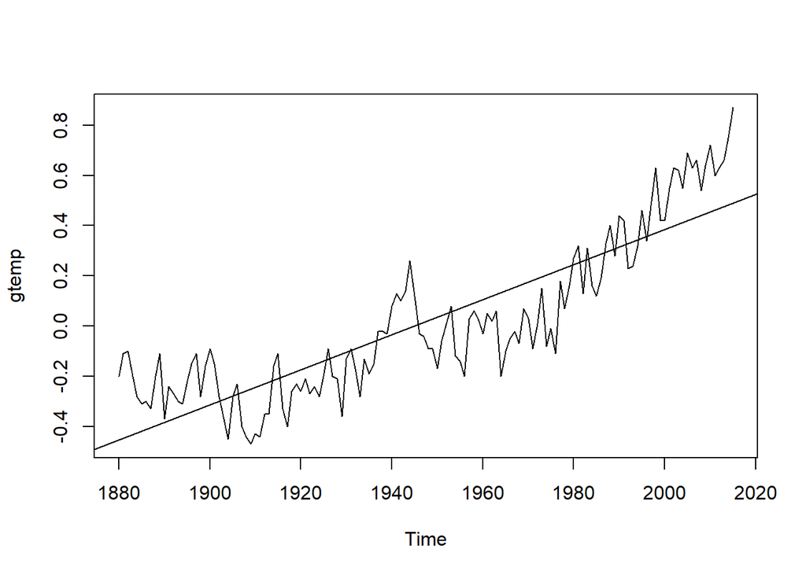

```r
plot(gtemp)
abline(reg=lm(gtemp~time(gtemp)))
```

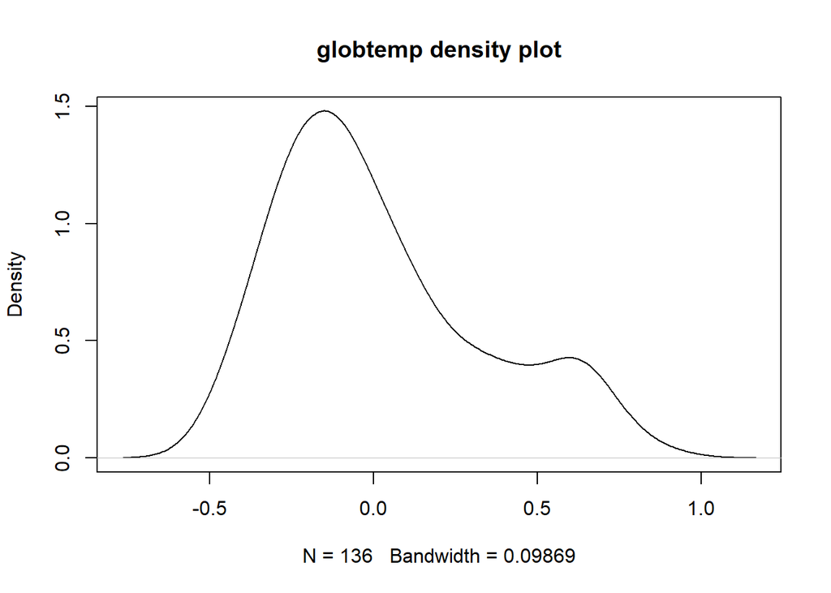

```r
##Density plot
plot(density(gtemp), main = "globtemp density plot")
```

#Data description